# Welcome to collapse: Advanced and Fast Data Transformation in R

Sebastian Krantz

2020-08-29

[figure not shown]

# Introduction

*collapse* is a C/C++ based package for data transformation and statistical computing in R. It was first released on CRAN end of March. The current version 1.3.1 is a mature package secured by > 7700 unit tests. *collapse* has 2 main aims:

1. To facilitate complex data transformation, exploration and computing tasks in R. *(In particular grouped and weighted statistical computations, advanced aggregation of multi-type data, advanced transformations of time series and panel data, and the manipulation of lists)*
2. To help make R code fast, flexible, parsimonious and programmer friendly. *(Provide order of magnitude performance improvements via C/C++ and highly optimized R code, broad object orientation and attribute preservation, and a flexible programming infrastructure in standard and non-standard evaluation)*

It is made compatible with *dplyr*, *data.table* and the *plm* approach to panel data. It can be installed in R using:

```r
install.packages('collapse')

# See Documentation
help('collapse-documentation')
```

With this post I want to formally and briefly introduce *collapse*, provide a basic demonstration of important features, and end with a small benchmark comparing *collapse* to *dplyr* and *data.table*. I hope to convince that *collapse* provides a superior architecture in terms of flexibility, functionality, performance, and programmability, to existing data manipulation frameworks in R.

# Demonstration

I will start by briefly demonstrating the *Fast Statistical Functions*, which are a central feature of *collapse*. Currently there are 14 of them (`fmean`, `fmedian`, `fmode`, `fsum`, `fprod`, `fsd`, `fvar`, `fmin`, `fmax`, `fnth`, `ffirst`, `flast`, `fNobs` and `fNdistinct`), they are all S3 generic and support fast grouped and weighted computations on vectors, matrices, data.frame’s, lists and grouped tibble’s (class *grouped_df*). Calling these functions on different objects yields column-wise statistical computations:

```r
library(collapse)
data("iris")            # iris dataset in base R
v <- iris$Sepal.Length  # Vector
d <- num_vars(iris)     # Saving numeric variables
g <- iris$Species       # Grouping variable (could also be a list of variables)

# Simple statistics
fmean(v)              # vector
```

```
## [1] 5.843333
```

```r
fsd(qM(d))            # matrix (qM is a faster as.matrix)
## Sepal.Length  Sepal.Width Petal.Length  Petal.Width
##    0.8280661    0.4358663    1.7652982    0.7622377
fmode(d)              # data.frame
## Sepal.Length  Sepal.Width Petal.Length  Petal.Width
##          5.0          3.0          1.5          0.2

# Preserving data structure
fmean(qM(d), drop = FALSE)     # still a matrix
```

```
##      Sepal.Length Sepal.Width Petal.Length Petal.Width
## [1,]     5.843333    3.057333        3.758    1.199333
```

```r
fmax(d, drop = FALSE)          # still a data.frame
```

```
##   Sepal.Length Sepal.Width Petal.Length Petal.Width
## 1          7.9         4.4          6.9         2.5
```

The functions `fmean`, `fmedian`, `fmode`, `fnth`, `fsum`, `fprod`, `fvar` and `fsd` additionally support weights[^1].

```r
# Weighted statistics, similarly for vectors and matrices ...
wt <- abs(rnorm(fnrow(iris)))
fmedian(d, w = wt)
## Sepal.Length  Sepal.Width Petal.Length  Petal.Width
##          5.8          3.0          4.3          1.3
```

The second argument of these functions is called `g` and supports vectors or lists of grouping variables for grouped computations. For functions supporting weights, `w` is the third argument. I note that all further examples generalize to computations on vectors and matrices.

```r
# Grouped statistics
fmean(d, g)
```

```
##            Sepal.Length Sepal.Width Petal.Length Petal.Width
## setosa            5.006       3.428        1.462       0.246
## versicolor        5.936       2.770        4.260       1.326
## virginica         6.588       2.974        5.552       2.026
```

```r
# Groupwise-weighted statistics
fmean(d, g, wt)
```

```
##            Sepal.Length Sepal.Width Petal.Length Petal.Width
## setosa         5.020002    3.438428     1.468919   0.2312987
## versicolor     5.960088    2.741734     4.268159   1.3264781
## virginica      6.657795    2.962662     5.548504   2.0271534
```

```r
fmode(d, g, wt, ties = "max")  # Grouped & weighted maximum mode..
```

```
##            Sepal.Length Sepal.Width Petal.Length Petal.Width
## setosa              5.1         3.4          1.5         0.2
## versicolor          6.0         3.0          4.5         1.5
## virginica           6.7         3.0          5.1         1.8
```

Grouping becomes more efficient when factors or grouping objects are passed to `g`. Factors can efficiently be created using the function `qF`, and grouping objects are efficiently created with the function `GRP`[^2] (more in the post about programming). As a final layer of complexity, all functions support transformations through the `TRA` argument.

```r
# Simple Transformations
head(fnth(v, 0.95, TRA = "replace"))  # replacing values with the 95th percentile
```

```
## [1] 7.25 7.25 7.25 7.25 7.25 7.25
```

```r
head(fsd(v, TRA = "/"))               # dividing by the overall standard-deviation (scaling)
```

```
## [1] 6.158928 5.917402 5.675875 5.555112 6.038165 6.521218
```

```r
# Grouped transformations
head(fsd(v, g, TRA = "/"))         # grouped scaling
```

```
## [1] 14.46851 13.90112 13.33372 13.05003 14.18481 15.31960
```

```r
head(fmin(v, g, TRA = "-"))        # setting the minimum value in each species to 0
```

```
## [1] 0.8 0.6 0.4 0.3 0.7 1.1
```

```r
head(fsum(v, g, TRA = "%"))        # computing percentages
```

```
## [1] 2.037555 1.957651 1.877747 1.837795 1.997603 2.157411
```

```r
head(ffirst(v, g, TRA = "%%"))     # taking modulus of first group-value, etc ...
```

```
## [1] 0.0 4.9 4.7 4.6 5.0 0.3
```

```r
# Grouped and weighted transformations
head(fmedian(v, g, wt, "-"))                      # Subtracting weighted group-medians
```

```
## [1]  0.1 -0.1 -0.3 -0.4  0.0  0.4
```

```r
head(fmode(d, g, wt, "replace", ties = "min"), 3) # replace with weighted minimum mode
```

```
##   Sepal.Length Sepal.Width Petal.Length Petal.Width
## 1          5.1         3.4          1.5         0.2
## 2          5.1         3.4          1.5         0.2
## 3          5.1         3.4          1.5         0.2
```

Currently there are 10 different replacing or sweeping operations supported by `TRA`, see `?TRA`. `TRA` can also be called directly as a function which performs simple and grouped replacing and sweeping operations:

```r
head(TRA(v, fmedian(v), "-"))                        # Same as fmedian(v, TRA = "-")
```

```
## [1] -0.7 -0.9 -1.1 -1.2 -0.8 -0.4
```

```r
head(TRA(d, BY(d, g, quantile, 0.05), "replace", g)) # Replace values with 5% percentile by species
```

```
##   Sepal.Length Sepal.Width Petal.Length Petal.Width
## 1          4.4           3          1.2         0.1
## 2          4.4           3          1.2         0.1
## 3          4.4           3          1.2         0.1
## 4          4.4           3          1.2         0.1
## 5          4.4           3          1.2         0.1
## 6          4.4           3          1.2         0.1
```

I have just used the function `BY`, which is also generic for split-apply-combine computing with user-supplied functions. Another useful function is `dapply` (data-apply), which supports quite efficient column- and row-wise operations on matrices and data frames.

Some common panel data transformations like between- and within-transformations (averaging and centering using the mean) are implemented slightly more memory efficient in the functions `fbetween` and `fwithin`. The function `fscale` also exists for fast (grouped, weighted) scaling and centering (standardizing) and mean-preserving scaling. These functions provide further options for data harmonization, such as centering on the overall data mean or scaling to the within-group standard deviation[^3] (as shown below), as well as scaling / centering to arbitrary supplied means and standard deviations.

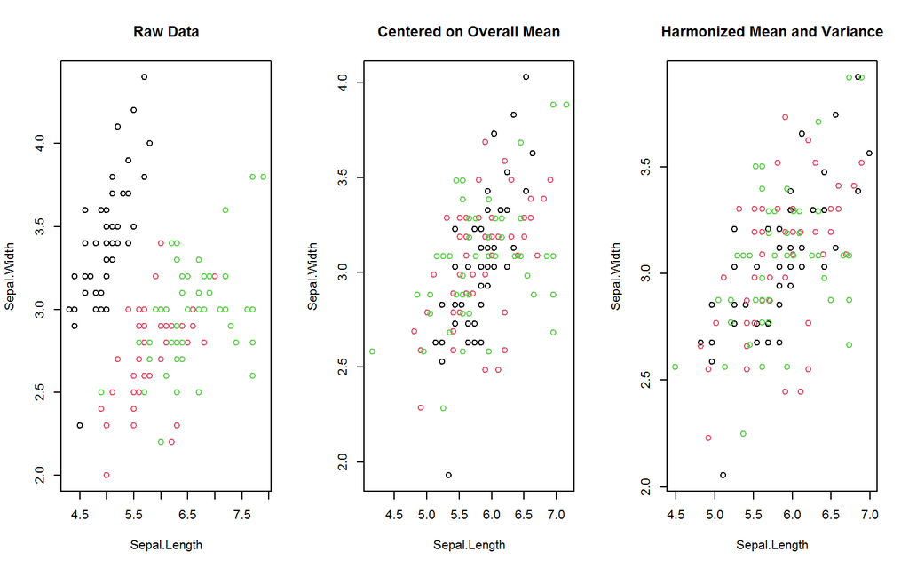

```r
oldpar <- par(mfrow = c(1,3))
plot(d[1:2], col = g, main = "Raw Data")
plot(fwithin(d[1:2], g, mean = "overall.mean"), col = g,
     main = "Centered on Overall Mean")
plot(fscale(d[1:2], g, mean = "overall.mean", sd = "within.sd"), col = g,
     main = "Harmonized Mean and Variance")
```

```r
par(oldpar)
```

For the manipulation of time series and panel series, *collapse* offers the functions `flag`, `fdiff` and `fgrowth`.

```r
head3 <- function(x) head(x, 3L)
head3(flag(EuStockMarkets, -1:1))      # A sequence of lags and leads
```

```
##       F1.DAX     DAX  L1.DAX F1.SMI    SMI L1.SMI F1.CAC    CAC L1.CAC F1.FTSE   FTSE L1.FTSE
## [1,] 1613.63 1628.75      NA 1688.5 1678.1     NA 1750.5 1772.8     NA  2460.2 2443.6      NA
## [2,] 1606.51 1613.63 1628.75 1678.6 1688.5 1678.1 1718.0 1750.5 1772.8  2448.2 2460.2  2443.6
## [3,] 1621.04 1606.51 1613.63 1684.1 1678.6 1688.5 1708.1 1718.0 1750.5  2470.4 2448.2  2460.2
```

```r
head3(fdiff(EuStockMarkets, 0:1, 1:2)) # Adding first and second difference of each variable
```

```
##          DAX D1.DAX D2.DAX    SMI D1.SMI D2.SMI    CAC D1.CAC D2.CAC   FTSE D1.FTSE D2.FTSE
## [1,] 1628.75     NA     NA 1678.1     NA     NA 1772.8     NA     NA 2443.6      NA      NA
## [2,] 1613.63 -15.12     NA 1688.5   10.4     NA 1750.5  -22.3     NA 2460.2    16.6      NA
## [3,] 1606.51  -7.12      8 1678.6   -9.9  -20.3 1718.0  -32.5  -10.2 2448.2   -12.0   -28.6
```

To facilitate programming and integration with *dplyr*, all functions introduced so far have a *grouped_df* method.

```r
library(dplyr)
iris %>% add_vars(wt) %>%             # Adding weight vector to dataset
  filter(Sepal.Length < fmean(Sepal.Length)) %>%
  select(Species, Sepal.Width:wt) %>%
  group_by(Species) %>%               # Frequency-weighted group-variance, default (keep.w = TRUE)
  fvar(wt) %>% arrange(sum.wt)        # also saves group weights in a column called 'sum.wt'
```

```
## # A tibble: 3 x 5
##   Species    sum.wt Sepal.Width Petal.Length Petal.Width
##   <fct>       <dbl>       <dbl>        <dbl>       <dbl>
## 1 virginica    3.30      0.0199       0.0539     0.0580
## 2 versicolor  17.9       0.0806       0.189      0.0278
## 3 setosa      37.3       0.126        0.0155     0.00725
```

Since *dplyr* operations are rather slow, *collapse* provides its own set of manipulation verbs with significant performance gains.

```r
iris %>% add_vars(wt) %>%
  fsubset(Sepal.Length < fmean(Sepal.Length), Species, Sepal.Width:wt) %>% # Fast selecting and subsetting
  fgroup_by(Species) %>%                     # Grouping (efficiently creates a grouped tibble)
  fvar(wt) %>%
  roworder(sum.wt)
```

```
## # A tibble: 3 x 5
##   Species    sum.wt Sepal.Width Petal.Length Petal.Width
##   <fct>       <dbl>       <dbl>        <dbl>       <dbl>
## 1 virginica    3.30      0.0199       0.0539     0.0580
## 2 versicolor  17.9       0.0806       0.189      0.0278
## 3 setosa      37.3       0.126        0.0155     0.00725
```

```r
iris %>% fgroup_by(Species) %>% num_vars %>% fwithin(wt) %>% head3  # Weighted demeaning
```

```
## # A tibble: 3 x 4
##   Sepal.Length Sepal.Width Petal.Length Petal.Width
##          <dbl>       <dbl>        <dbl>       <dbl>
## 1       0.0800      0.0616      -0.0689     -0.0313
## 2      -0.120      -0.438       -0.0689     -0.0313
## 3      -0.320      -0.238       -0.169      -0.0313
```

To take things a bit further, let’s consider some multilevel / panel data:

```r
# World Bank World Development Data - supplied with collapse
head3(wlddev)
```

```
##       country iso3c       date year decade     region     income  OECD PCGDP LIFEEX GINI       ODA
## 1 Afghanistan   AFG 1961-01-01 1960   1960 South Asia Low income FALSE    NA 32.292   NA 114440000
## 2 Afghanistan   AFG 1962-01-01 1961   1960 South Asia Low income FALSE    NA 32.742   NA 233350000
## 3 Afghanistan   AFG 1963-01-01 1962   1960 South Asia Low income FALSE    NA 33.185   NA 114880000
```

All variables in this data have labels stored in a ‘label’ attribute (the default if you import with *haven*). Variable labels can be accessed and set using `vlabels` and `vlabels<-`, and viewed together with names and classes using `namlab`. In general variable labels and other attributes will be preserved in when working with *collapse*. *collapse* provides some of the fastest and most advanced summary statistics:

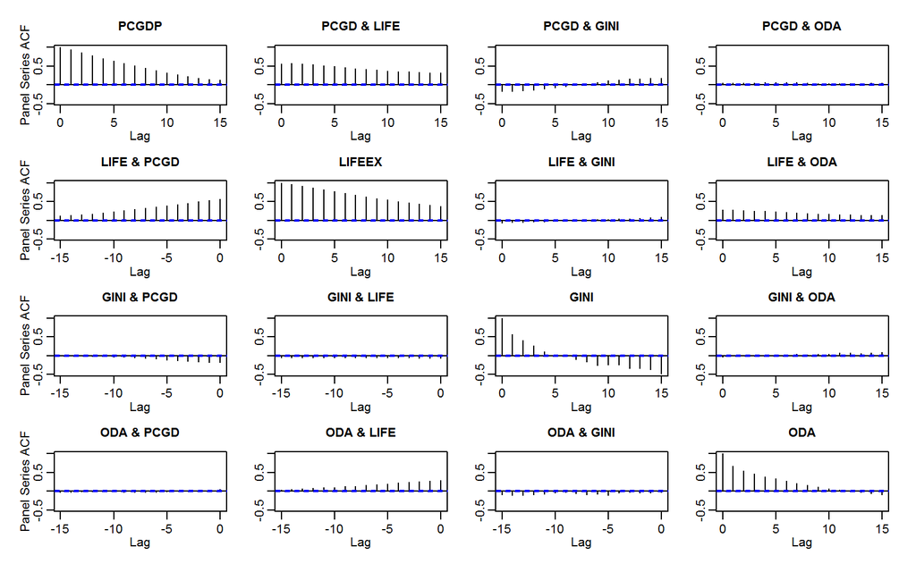

```r
# Distinct value count
fNdistinct(wlddev)
## country   iso3c    date    year  decade  region  income    OECD   PCGDP  LIFEEX    GINI     ODA
##     216     216      59      59       7       7       4       2    8995   10048     363    7564
# Use descr(wlddev) for a detailed description of each variable

# Checking for within-country variation
varying(wlddev, ~ iso3c)
## country    date    year  decade  region  income    OECD   PCGDP  LIFEEX    GINI     ODA
##   FALSE    TRUE    TRUE    TRUE   FALSE   FALSE   FALSE    TRUE    TRUE    TRUE    TRUE

# Panel-data statistics: Summarize GDP and GINI overall, between and within countries
qsu(wlddev, pid = PCGDP + GINI ~ iso3c,
    vlabels = TRUE, higher = TRUE)
## , , PCGDP: GDP per capita (constant 2010 US$)
##
##              N/T        Mean          SD          Min         Max    Skew     Kurt
## Overall     8995  11563.6529  18348.4052     131.6464   191586.64  3.1121  16.9585
## Between      203  12488.8577  19628.3668     255.3999  141165.083   3.214  17.2533
## Within   44.3103  11563.6529   6334.9523  -30529.0928   75348.067   0.696  17.0534
##
## , , GINI: GINI index (World Bank estimate)
##
##             N/T     Mean      SD      Min      Max    Skew    Kurt
## Overall    1356  39.3976  9.6764     16.2     65.8  0.4613  2.2932
## Between     161  39.5799  8.3679  23.3667  61.7143  0.5169  2.6715
## Within   8.4224  39.3976  3.0406  23.9576  54.7976  0.1421  5.7781

# Panel-data ACF: Efficient grouped standardizing and computing covariance with panel-lags
psacf(wlddev, ~ iso3c, ~ year, cols = 9:12)
```

*collapse* also has its own data aggregation command called `collap`. It is in many ways more flexible, for example you can apply multiple functions to each column and efficiently reshape the result.

```r
collap(wlddev, by = ~ region + income,
       FUN = list(fmean, fsd), cols = 9:12) %>% head3
```

```
##                region              income fmean.PCGDP  fsd.PCGDP fmean.LIFEEX fsd.LIFEEX fmean.GINI
## 1 East Asia & Pacific         High income   26042.280 14593.6195     73.22799   6.363266   32.80000
## 2 East Asia & Pacific Lower middle income    1621.178   908.9503     58.83796   9.383965   36.21081
## 3 East Asia & Pacific Upper middle income    3432.559  2418.0954     66.41750   6.451834   42.29524
##   fsd.GINI fmean.ODA   fsd.ODA
## 1 1.222020 177672692 337269272
## 2 4.830619 503484782 693802678
## 3 3.640621 242080501 604615277
```